# ODE_parameterization

Raine Detmer

4/6/2023

README: code for generating the ODE model parameter values from the sources listed in Table S1

# packages

```r
library("tidyverse")
library("lubridate")
```

# parameters

## rG

rG = gametophyte maturation rate (1/day)

Giant kelp gametophytes are thought to mature rapidly, with estimates for the time from spore settlement to production of sporophytes ranging from two weeks to around 30d (Reed et al. 1994, Deysher & Dean 1984), depending on irradiance levels and other local conditions. We assumed a mean maturation time of 20d, which corresponds to an instantanous maturation rate of 0.05/d:

```r
1/20# 0.05/d
```

```
## [1] 0.05
```

## muG

muG = gametophyte mortality rate (1/G/day)

Reed 1990 conducted a study of kelp recruitment on a reef in our study region (Naples reef near Santa Barbara, California). These field experiments suggest gametophyte mortality is very high (on the order of 0.00001 to 0.1% survival) and density-dependent (Fig. 4 in Reed 1990). Thus, we chose a fairly high value for density-dependent gametophyte mortality rate, 0.6/G/day, which could produced percent survival consistent with observed values:

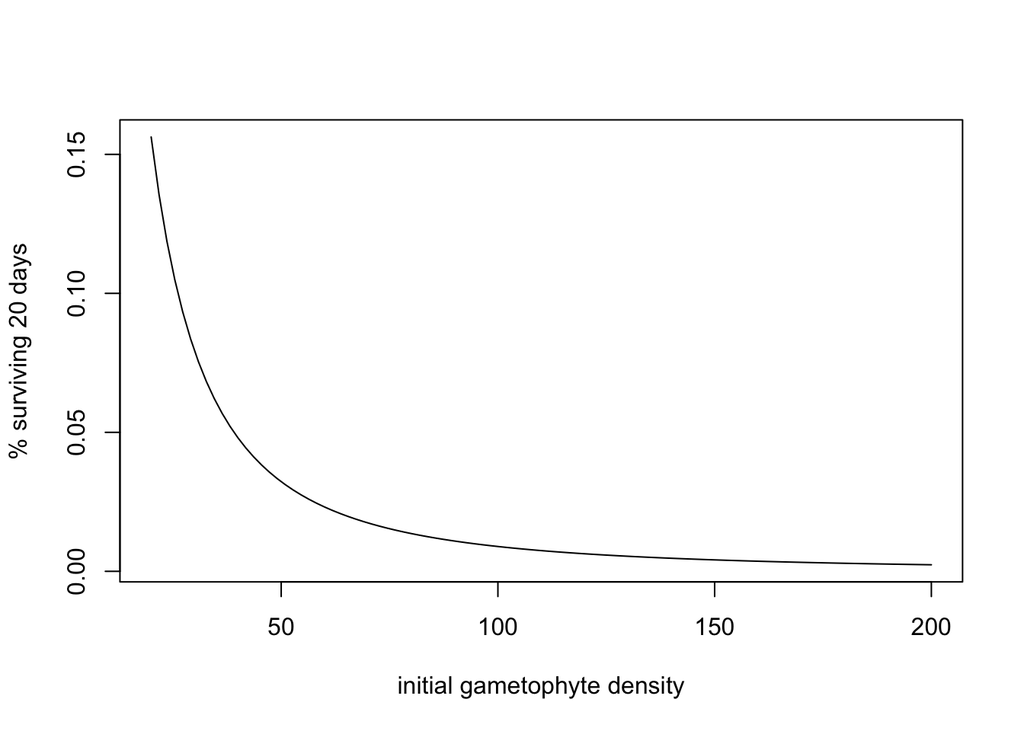

```r
# if dN/dt = -mN*N, then integral(1/(N^2)dN) = integral(-mdt) -> -1/N + c1 = -mt + c2 -> -1/N = -mt + c3, 1/N = mt-c
# so N(t) = 1/(m*t + c) where c = 1/N0 = 1/initial density

# assume gametophytes mature into sporophytes after 20d -> look at percent surviving after 20d
# range of initial gametophyte densities: 20 to 200 (which are reasonable inputs given our model parameters for adult kelp fecundity)
# plot percent surviving after 20d as a function of initial density, assuming a density-dependent mortality rate of 0.6/G/d:
plot(x = seq(from = 20, to = 200, length.out = 100), y = 1/(0.6*20+seq(from = 20, to = 200, length.out = 100))/seq(from = 20, to = 200, length.out = 100)*100, type = "l", xlab = "initial gametophyte density", ylab = "% surviving 20 days")
```

## rJ

rG = juvenile sporophyte maturation rate (1/day)

Giant kelp takes around 6-9 months to grow from settled spores to canopy forming adults (Dayton et al. 1984). For our default value, we assumed a mean sporophyte maturation rate of 250 days, which corresponds to an instantaneous maturation rate of 0.004/d

```r
1/250 # 0.004
```

```
## [1] 0.004
```

## muJ

muJ = juvenile sporophyte mortality rate (1/J/day)

Dayton et al. (1984) conducted a cohort analysis of giant kelp in a southern California kelp forest and found that 259/1543 juvenile sporophytes survived 6 months (Table 2 of Dayton et al. 1984). However, these data did not include information on initial densities, which we needed to estimate density-dependent mortality rate (for example due to competition for space/light). Therefore, we used the average non-zero juvenile sporophyte density from the SBC LTER and CINP KFMP data used in our random effect parameterization (see “ODE_random_effects.Rmd”) as our estimate of initial juvenile sporophyte density. We found that a mortality rate of 0.01/J/d produced survival consistent with Dayton et al. (1984)

```r
259/1543# around 17% survived 6 months
```

```
## [1] 0.1678548
```

```r
# in the LTER and KFM data (during our study period), the average non-zero density of juvenile sporophytes was 2.7 individuals/m2 (calculated in "ODE_random_effects.Rmd")

# if dN/dt = -mN*N, then integral(1/(N^2)dN) = integral(-mdt) -> -1/N + c1 = -mt + c2 -> -1/N = -mt + c3, 1/N = mt-c
# so N(t) = 1/(m*t + c) where c = 1/N0 = 1/initial density
# used trial and error to find a density dependent mortality rate that produced a 17% survival rate after 6 mo if starting at a density of 2.7 individuals/m2, found muJ = 0.01 works
1/(0.01*180 + 1/2.7)*(1/2.7)*100 # 17% survive 6 months (180 d) if starting with J = 2.7/m2 and mortality = 0.01/J/d
```

```
## [1] 17.06485
```

## K

K = adult sporophyte carrying capacity (individuals/m2)

Reed et al. (1988), in their description of giant kelp’s biology, report that adult plants “rarely exceed 1 plant/m2 in density”, which is consistent with the subset of SBC LTER and CINP KFMP data used in this study (90% quantile = 1.1 individuals/m2; see “ODE_random_effects.Rmd”). We therefore chose a default value of K=1.

## muA

muA = adult sporophyte mortality rate (1/day)

SBC LTER et al. 2023’s dataset (hereafter referred to as the “SBC LTER NPP data”) provide monthly estimates of adult plant loss rates at 3 sites along the coast of Santa Barbara, California. Individual plants are tagged and the number lost each month are measured in the following month. When plants are lost, new individuals are tagged to maintain a sample size of approximately 15 plants at each site. Instantaneous mortality rates (our muA parameter) for each site each month are calculated as

where T is the number of days in the sampling interval, P_0 is the number of tagged plants at the beginning of the interval, and P_T is the number of tagged plants at the end of the interval. See the protocol for more information: https://sbclter.msi.ucsb.edu/external/Reef/Protocols/Kelp_NPP/KelpNPP_20180522.pdf

Also see https://sbclter.msi.ucsb.edu/data/catalog/package/?package=knb-lter-sbc.112 for a general overview of this dataset

```r
# Package ID: knb-lter-sbc.112.7 Cataloging System:https://pasta.edirepository.org.
# Data set title: SBC LTER: REEF:  Net primary production, growth and standing crop of Macrocystis pyrifera in Southern California.
# Data set creator:    - Santa Barbara Coastal LTER
# Data set creator:  Andrew A Rassweiler -
# Data set creator:  Shannon Harrer -
# Data set creator:  Daniel C Reed -
# Data set creator:  Clint J Nelson -
# Data set creator:  Robert J Miller -
# Contact:    - Information Manager, Santa Barbara Coastal LTER   - sbclter@msi.ucsb.edu
# Stylesheet v2.11 for metadata conversion into program: John H. Porter, Univ. Virginia, jporter@virginia.edu

kelp_dem <-read.csv("https://pasta.lternet.edu/package/data/eml/knb-lter-sbc/112/5/62685a4fb61873c1843433a3364fd08a",header=F,skip=1,sep="," ,quot='"', col.names=c("Site", "Date","FSC_dry", "FSC_carbon", "FSC_nitrogen", "FSC_fraction_canopy", "Frond.density", "Plant_density", "Surface_Irradiance", "Bottom_Irradiance", "Subsurface_Irradiance", "Plant_loss_rate", "Frond_loss_rate", "Cut_frond_loss_rate", "Blade_loss_rate", "Dissolved_loss_rate", "Carbon_lost_as_plants", "Carbon_lost_as_fronds", "Carbon_lost_as_cut_fronds", "Carbon_lost_as_blades", "Carbon_lost_as_dissolved", "SE_FSC_dry", "SE_FSC_carbon", "SE_FSC_nitrogen", "SE_fraction_canopy", "SE_frond_density", "SE_plant_density", "SE_plant_loss_rate",  "SE_frond_loss_rate", "SE_cut_frond_loss_rate", "SE_blade_loss_rate", "SE_dissolved_loss_rate", "SE_carbon_lost_as_plants", "SE_carbon_lost_as_fronds", "SE_carbon_lost_as_cut", "SE_carbon_lost_as_blades","SE_carbon_lost_as_dissolved"), check.names=TRUE)

#dim(kelp_dem)
# fill in the NAs
kelp_dem <- kelp_dem %>% mutate_at(c(colnames( kelp_dem[3:37])), list(~if_else(.==-99999, as.numeric(NA), .)))

#max(kelp_dem$Date)

# select just columns of interest, get month and date, and filter out only the values that were recorded at the time of this study (since this is an ongoing data set)
kelp_dem1 <- kelp_dem[, c(1, 2, 3, 6, 7, 8, 12, 13, 15)]%>% mutate(Month = month(Date), year = year(Date)) %>% filter(year < 2022)

#View(kelp_dem1)
```

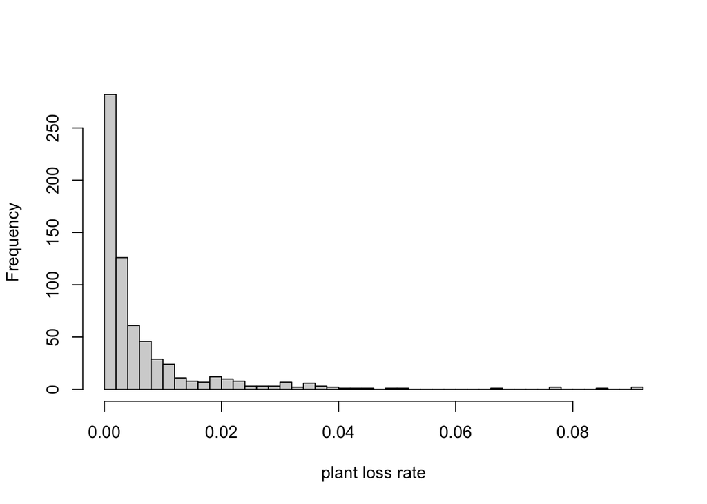

```r
# check the distribution:
hist(kelp_dem1$Plant_loss_rate, n = 50, xlab = "plant loss rate", main=NA) # not normally distributed
```

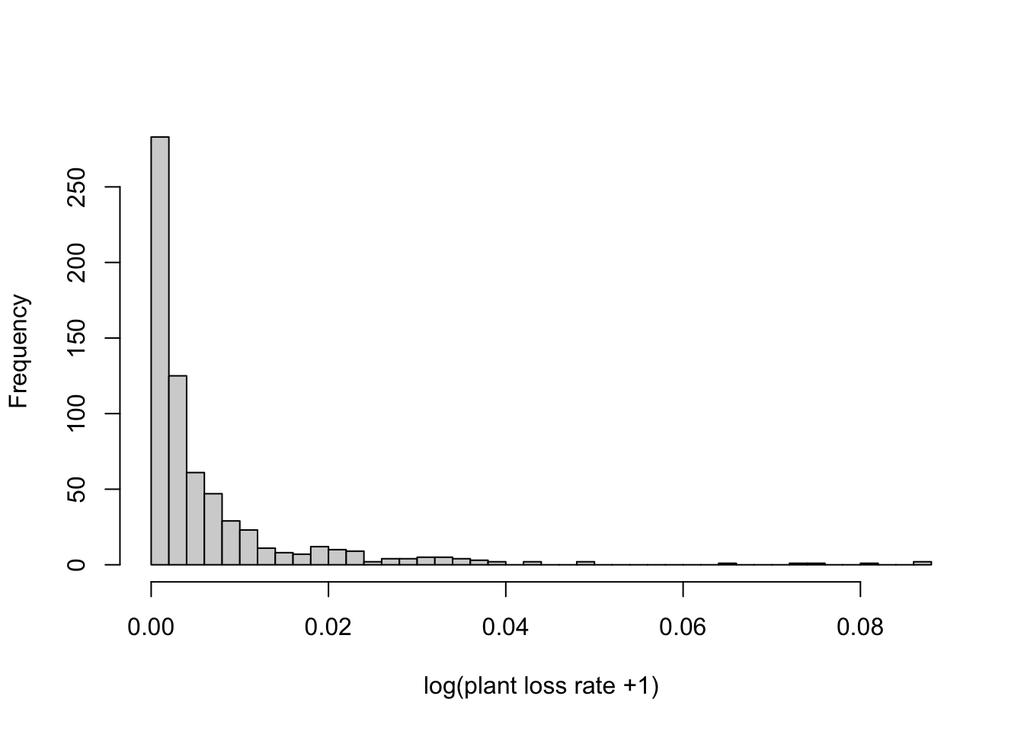

```r
hist(log(kelp_dem1$Plant_loss_rate+1), n = 50, xlab = "log(plant loss rate +1)", main = NA) # log transforming didn't help
```

```r
# because of the shape of the distribution, instead of using the overall mean use the mean of the values between the 25th and 75th quantiles (i.e., the mean of the central 50% of observed values)
kelp_muA_sum <- kelp_dem1 %>% mutate(q25 = quantile(Plant_loss_rate, 0.25, na.rm = T), q75 = quantile(Plant_loss_rate, 0.75, na.rm = T)) %>% ungroup() %>% filter(Plant_loss_rate>= q25) %>% filter(Plant_loss_rate <= q75) %>% group_by(q25, q75) %>% summarize(meanloss = mean(Plant_loss_rate, na.rm = T))
```

[output not shown]

```r
kelp_muA_sum$meanloss # 0.001777 -> choose muA = 0.002 as default
```

```
## [1] 0.001777575
```

Also estimate seasonal changes in muA for the ODE-GLMM comparison simulations (in “ODE_GLMM_comparison.Rmd”):

```r
# group the data into quarters, get the 25% and 75% quantiles for each quarter, then get the mean values within this region
kelp_muA_qsum <- kelp_dem1 %>% mutate(quarter = if_else(Month %in% c(1, 2, 3), 1, if_else(Month %in% c(4, 5, 6), 2, if_else(Month %in% c(7, 8,9), 3, 4)))) %>% group_by(quarter) %>% mutate(q25 = quantile(Plant_loss_rate, 0.25, na.rm = T), q75 = quantile(Plant_loss_rate, 0.75, na.rm = T)) %>% ungroup() %>% filter(Plant_loss_rate>= q25) %>% filter(Plant_loss_rate <= q75) %>% group_by(quarter, q25, q75) %>% summarize(meanloss = mean(Plant_loss_rate, na.rm = T))
kelp_muA_qsum # higher in Q1 (likely due to wave disturbance), where mean = 0.007
```

```
## # A tibble: 4 x 4
## # Groups:   quarter, q25 [4]
##   quarter     q25     q75 meanloss
##     <dbl>   <dbl>   <dbl>    <dbl>
## 1       1 0.00205 0.0171  0.00697
## 2       2 0       0.00722 0.00160
## 3       3 0       0.00379 0.000564
## 4       4 0       0.00584 0.00173
```

```r
# Q3 has lower loss rates than 2 and 4, but the difference in means is much smaller than the difference between any of these quarters and Q1, so for simplicity, group the other 3 quarters together
mean(kelp_muA_qsum$meanloss[which(kelp_muA_qsum$quarter != 1)]) # mean = 0.001
```

```
## [1] 0.001296209
```

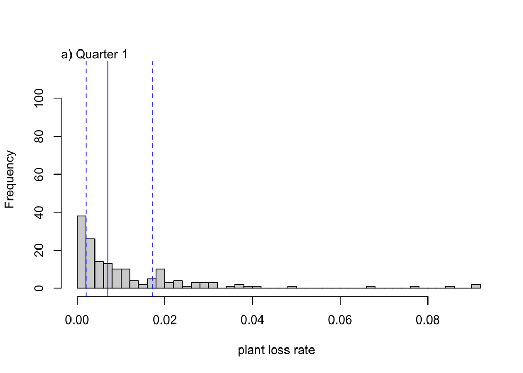

```r
# check histograms to make sure these values are reasonable
hist(kelp_dem1$Plant_loss_rate[which(kelp_dem1$Month %in% c(1, 2, 3))], n = 40, xlab = "plant loss rate", main = NA, xlim = c(0, max(kelp_dem1$Plant_loss_rate[which(kelp_dem1$Month %in% c(1, 2, 3))], na.rm = T)), ylim = c(0, 115))
abline(v = kelp_muA_qsum$q25[which(kelp_muA_qsum$quarter==1)], lty = 2, col = "blue")
abline(v = kelp_muA_qsum$q75[which(kelp_muA_qsum$quarter==1)], lty = 2, col = "blue")
abline(v = 0.007, lty = 1, col = "blue")
mtext(side = 3, text = "a) Quarter 1", adj = 0)
```

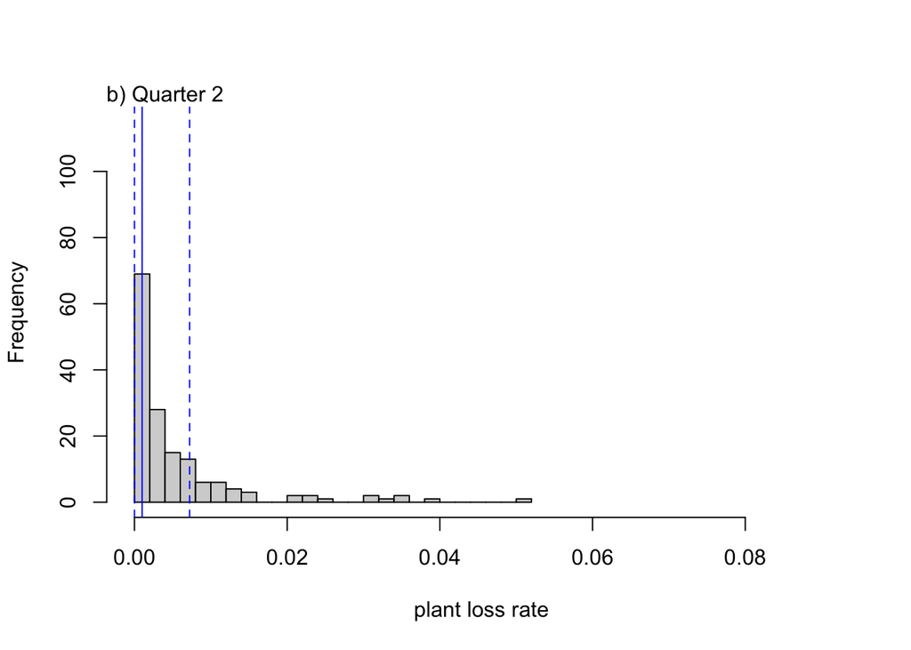

```r
# quarter 2
hist(kelp_dem1$Plant_loss_rate[which(kelp_dem1$Month %in% c(4, 5, 6))], n = 20, xlab = "plant loss rate", main = NA, xlim = c(0, max(kelp_dem1$Plant_loss_rate[which(kelp_dem1$Month %in% c(1, 2, 3))], na.rm = T)), ylim = c(0, 115))
abline(v = kelp_muA_qsum$q25[which(kelp_muA_qsum$quarter==2)], lty = 2, col = "blue")
abline(v = kelp_muA_qsum$q75[which(kelp_muA_qsum$quarter==2)], lty = 2, col = "blue")
abline(v = 0.001, lty = 1, col = "blue")
mtext(side = 3, text = "b) Quarter 2", adj = 0)
```

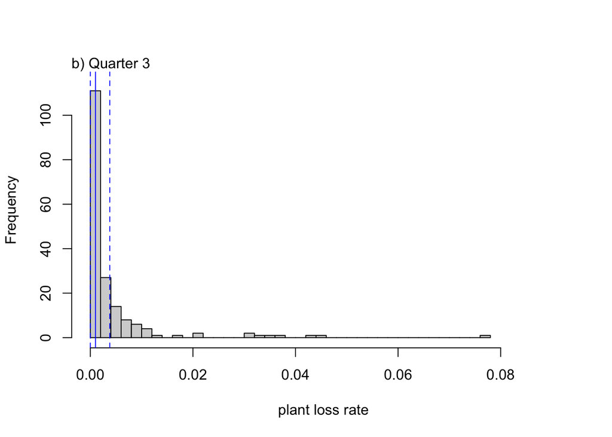

```r
# quarter 3
hist(kelp_dem1$Plant_loss_rate[which(kelp_dem1$Month %in% c(7, 8, 9))], n = 40, xlab = "plant loss rate", main = NA, xlim = c(0, max(kelp_dem1$Plant_loss_rate[which(kelp_dem1$Month %in% c(1, 2, 3))], na.rm = T)), ylim = c(0, 115))
abline(v = kelp_muA_qsum$q25[which(kelp_muA_qsum$quarter==3)], lty = 2, col = "blue")
abline(v = kelp_muA_qsum$q75[which(kelp_muA_qsum$quarter==3)], lty = 2, col = "blue")
abline(v = 0.001, lty = 1, col = "blue")
mtext(side = 3, text = "b) Quarter 3", adj = 0)
```

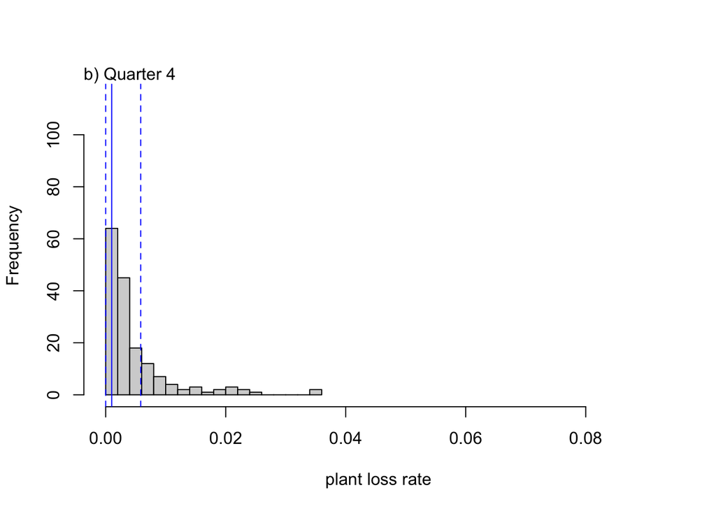

```r
# quarter 4
hist(kelp_dem1$Plant_loss_rate[which(kelp_dem1$Month %in% c(10, 11, 12))], n = 20, xlab = "plant loss rate", main = NA, xlim = c(0, max(kelp_dem1$Plant_loss_rate[which(kelp_dem1$Month %in% c(1, 2, 3))], na.rm = T)), ylim = c(0, 115))
abline(v = kelp_muA_qsum$q25[which(kelp_muA_qsum$quarter==4)], lty = 2, col = "blue")
abline(v = kelp_muA_qsum$q75[which(kelp_muA_qsum$quarter==4)], lty = 2, col = "blue")
abline(v = 0.001, lty = 1, col = "blue")
mtext(side = 3, text = "b) Quarter 4", adj = 0)
```

## b

b = biomass per adult sporophyte individual (kg/individual)

Use the data from the annual kelp surveys conducted by the SBC LTER (SBC LTER et al. 2022) and CINP KFMP (Kushner et al. 2013). In these surveys, divers record the number and size (=number of fronds) of kelp plants in permanent transects. More information on the kelp survey data can be found at:

https://sbclter.msi.ucsb.edu/data/catalog/package/?package=knb-lter-sbc.18 (SBC LTER et al. 2022) and

https://esapubs.org/archive/ecol/E094/245/metadata.php#_Hlk327197899 (Kushner et al. 2013)

The SBC LTER NPP data (SBC LTER et al. 2023) that was used to estimate muA above also includes regression coefficients for converting frond density to biomass, which we used to approximate plant biomass from frond counts. Information on the estimation of these regession coefficients can be found at: https://sbclter.msi.ucsb.edu/data/catalog/package/?package=knb-lter-sbc.112

```r
# LTER kelp survey data
# Package ID: knb-lter-sbc.18.26 Cataloging System:https://pasta.edirepository.org.
# Data set title: SBC LTER: Reef: Kelp Forest Community Dynamics: Abundance and size of Giant Kelp (Macrocystis Pyrifera), ongoing since 2000.
# Data set creator:    - Santa Barbara Coastal LTER
# Data set creator:  Daniel C Reed -
# Data set creator:  Robert J Miller -
# Contact:    - Information Manager, Santa Barbara Coastal LTER   - sbclter@msi.ucsb.edu
# Stylesheet v2.11 for metadata conversion into program: John H. Porter, Univ. Virginia, jporter@virginia.edu

 lter_kelp <-read.csv("https://pasta.lternet.edu/package/data/eml/knb-lter-sbc/18/26/e0144d254ab3b45fa1cd9d0a0420e2e8",header=F, skip=1,sep=",",quot='"', col.names=c("YEAR","MONTH","DATE","SITE","TRANSECT","QUAD", "SIDE","SP_CODE","FRONDS","HLD_DIAM","AREA","OBS_CODE","NOTES","SCIENTIFIC_NAME","COMMON_NAME","TAXON_KINGDOM","TAXON_PHYLUM","TAXON_CLASS","TAXON_ORDER","TAXON_FAMILY","TAXON_GENUS","GROUP","SURVEY", "MOBILITY","GROWTH_MORPH"), check.names=TRUE)

# replace NAs
 lter_kelp <-  lter_kelp %>% mutate_at(c(colnames(lter_kelp[9:11])), list(~if_else(.==-99999, as.integer(NA), .)))


 # KFM giant kelp size-frequency data from Kushner et al. (2013):
 kfm_kelp <- read.csv("https://esapubs.org/archive/ecol/E094/245/Giant%20kelp%20size%20frequency.csv")

 # regression pars to convert fronds to biomass (from SBC LTER NPP data)
 # Package ID: knb-lter-sbc.112.7 Cataloging System:https://pasta.edirepository.org.
# Data set title: SBC LTER: REEF:  Net primary production, growth and standing crop of Macrocystis pyrifera in Southern California.
# Data set creator:    - Santa Barbara Coastal LTER
# Data set creator:  Andrew A Rassweiler -
# Data set creator:  Shannon Harrer -
# Data set creator:  Daniel C Reed -
# Data set creator:  Clint J Nelson -
# Data set creator:  Robert J Miller -
# Contact:    - Information Manager, Santa Barbara Coastal LTER   - sbclter@msi.ucsb.edu
# Stylesheet v2.11 for metadata conversion into program: John H. Porter, Univ. Virginia, jporter@virginia.edu
 kelp_regpars <-read.csv("https://pasta.lternet.edu/package/data/eml/knb-lter-sbc/112/5/6bc968141edf7b9e0a6bac923f5f78b2", header=F,skip=1,sep="," ,quot='"', col.names=c("Model", "Month", "Independent_variable", "Dependent_variable", "Slope", "Intercept", "pvalue", "rsquare","N"), check.names=TRUE)

 #subset out model 1 (indep variable = fronds/m2 in the specified month, dep variable = kg dry mass/m2 in the specified month)
kelp_regpars <- kelp_regpars %>% filter(Model==1) %>% dplyr::select(Month, Independent_variable, Dependent_variable, Slope, Intercept) %>% rename(MONTH = Month) #%>% mutate(MONTH = as.factor(MONTH))
```

```r
# format the data
lter_kelp2 <- lter_kelp %>% filter(YEAR<2023) %>% mutate(site.trans = paste(SITE, TRANSECT, sep = ".")) %>% rename(year = YEAR) %>% select(-TAXON_KINGDOM, -TAXON_PHYLUM, - TAXON_CLASS, -TAXON_ORDER, -TAXON_FAMILY, -TAXON_GENUS, -GROUP, -SURVEY, -MOBILITY, -GROWTH_MORPH) %>% left_join(kelp_regpars, by = "MONTH") %>%  mutate(BIOMASS = (FRONDS*Slope + Intercept)/0.094)%>% mutate(PLANTS = if_else(FRONDS>0, 1, if_else(FRONDS==0, 0, as.double(NA)))) %>% group_by(year, MONTH, DATE, site.trans, QUAD, SIDE, AREA) %>% summarize(n_plants = sum(PLANTS, na.rm=T), AREA = max(AREA),mean_mass = mean(BIOMASS, na.rm = T)) %>% group_by(year, site.trans) %>% summarize(kelp_dens = sum(n_plants)/sum(AREA), mean_mass = mean(mean_mass))%>% filter(kelp_dens>0 & is.na(mean_mass)==F) %>% dplyr::select(-kelp_dens) #%>% filter(mean_mass>0)
kfm_kelp2 <- kfm_kelp  %>% mutate(Site = as.character(Site)) %>% rename(site_name = Site) %>% rename(year = Year)
# convert date to date format in order to get the month
kfm_kelp2$Date <- as.Date(kfm_kelp2$Date,format='%d%b%Y')
kfm_kelp2 <- kfm_kelp2 %>% mutate(MONTH = month(Date))%>% left_join(kelp_regpars, by = "MONTH") %>%  mutate(BIOMASS = (StipeCount*Slope + Intercept)/0.094) %>% group_by(site_name, year) %>% summarize(mean_mass=mean(BIOMASS))
```

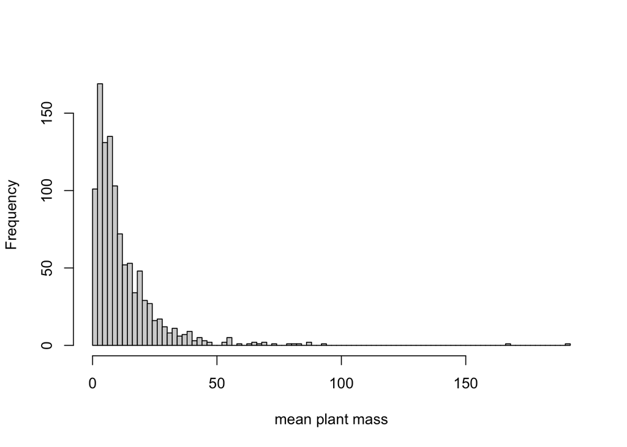

```r
# look at the distribution of values
hist(c(lter_kelp2$mean_mass, kfm_kelp2$mean_mass), n = 100, xlab = "mean plant mass", main = NA) #looks log-normally distributed
```

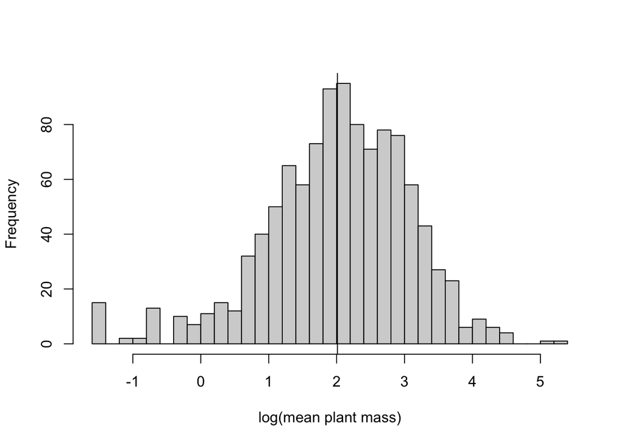

```r
hist(log(c(lter_kelp2$mean_mass, kfm_kelp2$mean_mass)), n =40, xlab = "log(mean plant mass)", main = NA) # approximately normal so use the mean of the log values (then convert back to raw scale)
abline(v=mean(log(c(lter_kelp2$mean_mass, kfm_kelp2$mean_mass))))
```

```r
exp(mean(log(c(lter_kelp2$mean_mass, kfm_kelp2$mean_mass)))) # around 7 kg/plant
```

```
## [1] 7.474611
```

## rho

rho = adult sporophyte spore production rate (spores/kg/day)

We estimated this by choosing a value that produced biologically reasonable dynamics (i.e., in the absence of external spore supply and urchin grazing, a kelp population could grow from near zero to carrying capacity in 6-9 months; Dayton et al. 1984). See the code for Fig. S6 in “ODE_supp_figs.Rmd” for this simulation.

## d

d = adult sporophyte drift production rate (kg drift/kg/day)

In addition to plant loss, the SBC LTER NPP dataset (SBC LTER et al. 2023) also includes measures of instantaneous loss of individual fronds and blades (e.g., due to senescence). More details on how these are measured can be found at https://sbclter.msi.ucsb.edu/external/Reef/Protocols/Kelp_NPP/KelpNPP_20180522.pdf

Following Rennick et al. (2022), we estimated per-biomass rates of drift production as the sum of frond and blade loss rates:

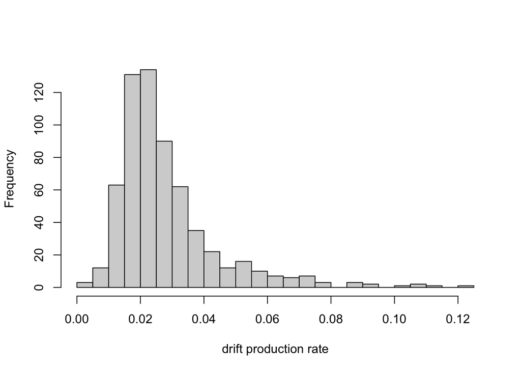

```r
kelp_dem2 <- kelp_dem1 # same data set as used to estimate muA (SBC LTER NPP data)
kelp_dem2$Frond_Blade_loss_rate <- kelp_dem1$Frond_loss_rate + kelp_dem1$Blade_loss_rate

hist(kelp_dem2$Frond_Blade_loss_rate, n = 20, xlab = "drift production rate", main = NA)
```

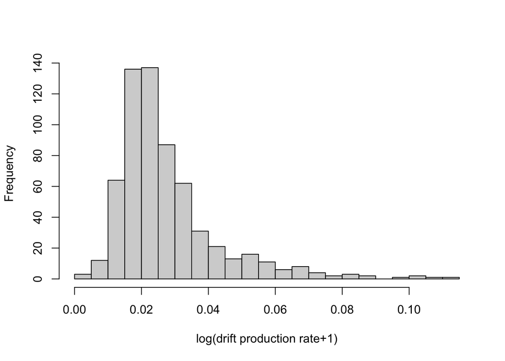

```r
hist(log(kelp_dem2$Frond_Blade_loss_rate+1), n = 20, xlab = "log(drift production rate+1)", main = NA)# log transforming didn't change the shape of the distribution very much so just use the raw data
```

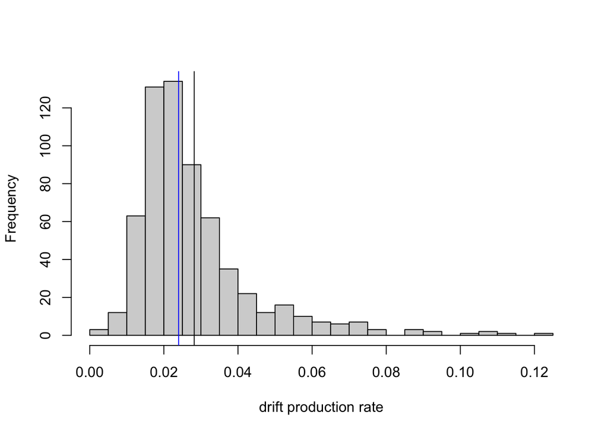

```r
# look at the mean and the median
hist(kelp_dem2$Frond_Blade_loss_rate, n = 20, xlab = "drift production rate", main = NA)
abline(v=mean(kelp_dem2$Frond_Blade_loss_rate, na.rm = T))
abline(v=median(kelp_dem2$Frond_Blade_loss_rate, na.rm = T), col = "blue")
```

```r
# use the median as the default value of d
median(kelp_dem2$Frond_Blade_loss_rate, na.rm = T) #0.024
```

```
## [1] 0.02397311
```

## gd

gd = rate of drift consumption by urchins (kg drift/urchin/day)

To estimate this parameter, we used the data on urchin drift consumption rates from mesocosm experiments performed by Rennick et al. 2022 (dataset published by DiFiore et al. 2021; more information available at https://sbclter.msi.ucsb.edu/data/catalog/package/?package=knb-lter-sbc.145)

```r
# Package ID: knb-lter-sbc.145.1 Cataloging System:https://pasta.edirepository.org.
# Data set title: SBC LTER: Sea urchin foraging rates on giant kelp.
# Data set creator:    - Santa Barbara Coastal LTER
# Data set creator:  Bartholomew DiFiore -
# Data set creator:  Mae Rennick -
# Data set creator:  Joseph Curtis -
# Data set creator:  Daniel C Reed -
# Data set creator:  Adrian Stier -
# Contact:    - Information Manager, Santa Barbara Coastal LTER   - sbclter@msi.ucsb.edu
# Stylesheet v2.11 for metadata conversion into program: John H. Porter, Univ. Virginia, jporter@virginia.edu

# urchins1: kelp foraging rates as a function of urchin density (biomass was varied by manipulating the number of urchins in a tank)
 urchins1 <-read.csv("https://pasta.lternet.edu/package/data/eml/knb-lter-sbc/145/1/adddbb021b16819a5fbac2475b5478b9",header=F, skip=1 ,sep="," ,quot='"', col.names=c("date", "trial_number", "p_r", "trial_id", "total_time", "tank", "urchin_density", "urchin_size", "urchin_mass", "kelp_in", "kelp_out", "mortality"), check.names=TRUE)

# urchins2: kelp foraging rates as a function of urchin body size (biomass was varied by manipulating the size of urchins in a tank)
 urchins2 <-read.csv("https://pasta.lternet.edu/package/data/eml/knb-lter-sbc/145/1/5fea89735f07cf6aefc2b239518e6120",header=F,skip=1 ,sep=",", col.names=c("trial_id","sp", "urchin_density", "size_class", "test_diameter","mass", "kelp_in", "kelp_out", "time_ran"), check.names=TRUE)
```

Rennick et al. (2022) analyzed these data and found no evidence of non-linear functional responses. For simplicity, we therefore pooled all treatments and species (purple and red urchins) together in order to get an overall estimate of per capita drift consumption rate

```r
# format the data from the first set of experiments (varying numbers of urchins per tank)
#check that mortality was low
#sort(urchins1$mortality/urchins1$urchin_density)

#filter out trial with 14% mortality, convert trial time from hours to days, get kelp consumed and kelp consumed per urchin (can divide by density because density = number of urchins per tank).
urchins1.2 <- urchins1 %>% filter(mortality/urchin_density<0.1) %>% mutate(total_time_d = total_time/24) %>% mutate(kelp_consumed = kelp_in - kelp_out) %>% mutate(urchin_consumption_rate = kelp_consumed/urchin_density/total_time_d/1000) %>% filter(kelp_consumed>=0)%>% #filter out cases where kelp out was greater than kelp in
group_by(date, trial_number, p_r, trial_id, total_time, tank, urchin_density, kelp_in, kelp_out, mortality, total_time_d, kelp_consumed) %>% summarize(urchin_consumption_rate = mean(urchin_consumption_rate))
```

[output not shown]

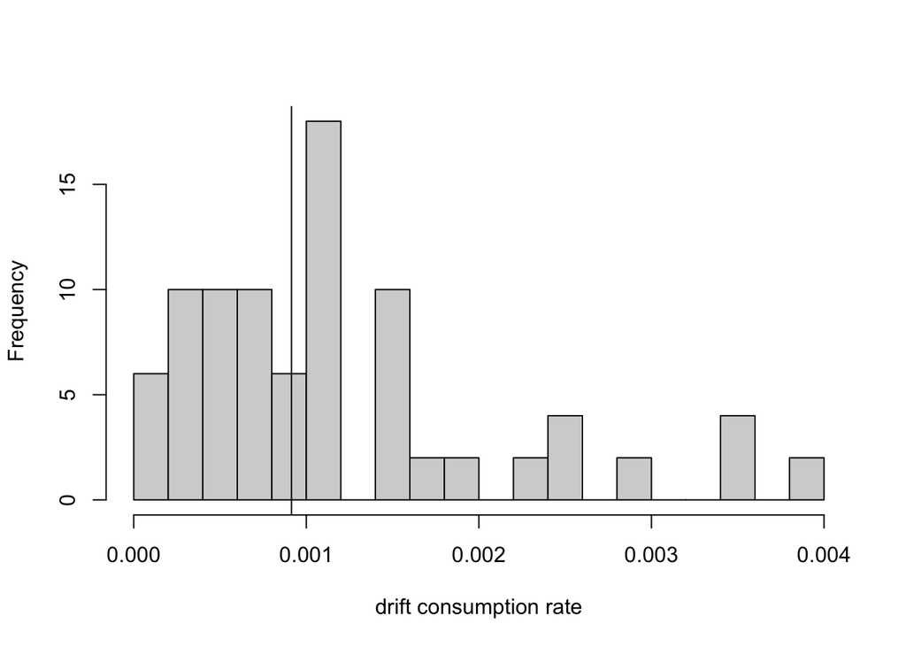

```r
mean_consumption1 <- mean(urchins1.2$urchin_consumption_rate)

# format the data from the second set of experiments (all tanks had same density but urchin size varied)
urchins2.2 <- urchins2 %>%  mutate(total_time_d = time_ran/24) %>% mutate(kelp_consumed = kelp_in - kelp_out) %>% mutate(urchin_consumption_rate = kelp_consumed/urchin_density/total_time_d/1000) %>% filter(kelp_consumed>=0)#filter out cases where kelp out was greater than kelp in

mean_consumption2 <- mean(urchins2.2$urchin_consumption_rate)


# look at the distribution across all treatments and both species
hist(c(urchins1.2$urchin_consumption_rate, urchins1.2$urchin_consumption_rate), n = 15, xlab = "drift consumption rate", main = NA)
abline(v = mean(c(urchins1.2$urchin_consumption_rate, urchins2.2$urchin_consumption_rate)))
```

```r
# get the overall mean consumption rate
mean(c(mean_consumption1, mean_consumption2)) # about 0.0011
```

```
## [1] 0.00104078
```

## g, qG, qJ

g = maximum urchin grazing rate on adult sporophytes (individuals/urchin/d)

qG = vulnerability of gametophytes to grazing (relative to adult sporophytes)

qJ = vulnerability of juvenile sporophytes to grazing (relative to adult sporophytes)

Karatayev et al. (2021) fit a model of giant kelp dynamics (with behaviorally-mediated grazing) to CINP KFMP data from the California Channel Islands. Table 1 of their paper gives parameter estimates for the best-fitting model, which includes maximum grazing rates on adult and juvenile giant kelp. Converting these to units and parameters used in our model gives values of g = 0.025/urchin/d and qG = qJ = 1.2:

```r
#max grazing rate on adult kelp delta_A = 9/urchin/yr
9/365# 0.025/urchin/d
```

```
## [1] 0.02465753
```

```r
#max grazing rate on kelp recruits delta_R = 10.6/urchin/yr and max grazing rate on adult kelp delta_A = 9/urchin/yr
# ratio of grazing on recruits to grazing on juveniles
10.6/9# 1.1778
```

```
## [1] 1.177778
```

```r
# choose qG = qJ = 1.2
```

## p

p = proportional reduction in grazing if rates of drift production and consumption are equal

Karatayev et al. (2021) modeled urchin grazing using a Type IV functional response and estimated this function’s parameters by fitting it to empirical data from the Channel Islands. Their function differed from ours in that grazing pressure depended on kelp density (i.e., drift production) only, rather than the ratio of production to consumption, so the two cannot be directly compared. However, they are closely related and, in the absence of other data, we estimated p by choosing a value for which our function produced a similar proportional decline in grazing rate when production and consumption rates are equal (ratio = 1) as Karatayev et al.’s function did when kelp density was equal to 1 individual/m2 (our value of kelp carrying capacity). A value of p=0.1 produced a good approximation:

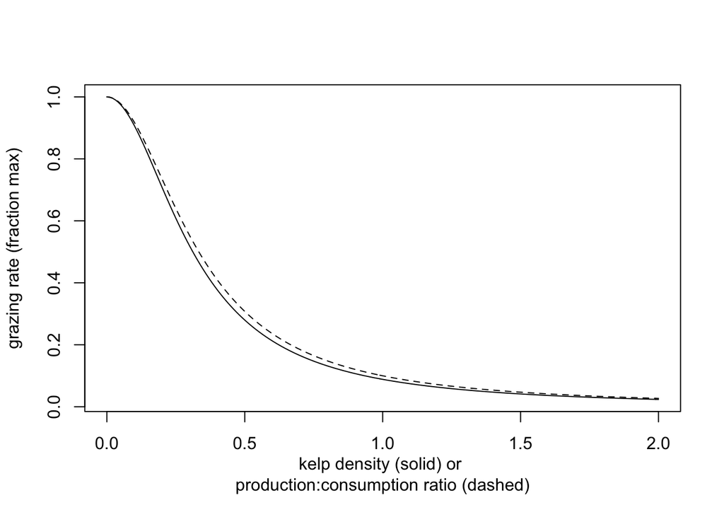

```r
# Karatayev et al. behavior function: grazing inhibition by adult kelp eta_A = 10.3/kelp dens^2, where the behavioral decline is 1/(1 + eta_A*A^2), where eta_A = grazing inhibition by adult kelp= 10.3/kelp dens^2; they also included potential effects of predators as e^(-eta_P*P)/(1 + eta_A*A^2) but for simplicity we set predators to 0

# plot Karatayev et al.'s function and the behavioral function used in this study (with a value of p=0.1, which produces a close match)
plot(x = seq(from = 0, to = 2, by = 0.01), y = 1/(1+ 10.3*(seq(from = 0, to = 2, by = 0.01))^2), type = "l", xlab = "kelp density (solid) or \nproduction:consumption ratio (dashed)", ylab = "grazing rate (fraction max)")
lines(x=seq(from = 0, to = 2, by = 0.01), y = 1/(1+(1-0.1)/0.1*(seq(from = 0, to = 2, by = 0.01))^2), type = "l", lty = 2)
```

# references

Dayton PK, Currie V, Gerrodette T, Keller BD, Rosenthal R, Tresca DV (1984) Patch Dynamics and Stability of Some California Kelp Communities. Ecological Monographs 54:253–289.

Deysher LE, Dean TA (1984) Critical irradiance levels and the interactive effects of quantum irradiance and dose on gametogenesis in the giant kelp, macrocystis pyrifera1. J Phycol 20:520–524.

DiFiore B, Rennick M, Curtis J, Reed DC, Stier A (2021) SBC LTER: Sea urchin foraging rates on giant kelp.

Karatayev VA, Baskett ML, Kushner DJ, Shears NT, Caselle JE, Boettiger C (2021) Grazer behaviour can regulate large‐scale patterning of community states. Ecology Letters 24:1917–1929.

Kushner D, Rassweiler A, McLaughlin JP, Lafferty KD (2013) A multi-decade time series of kelp forest community structure at the California Channel Islands. Ecology 94:2655.

Reed DC, Laur DR, Ebeling AW (1988) Variation in Algal Dispersal and Recruitment: The Importance of Episodic Events. Ecological Monographs 58:321–335.

Reed DC (1990) The Effects of Variable Settlement and Early Competition on Patterns of Kelp Recruitment. Ecology 71:776–787.

Reed, D. C., R. J. Lewis, and M. Anghera. 1994. Effects of an open coast oil production outfall on patterns of giant kelp (Macrocystis pyrifera) recruitment. Marine Biology 120:26–31.

Rennick M, DiFiore BP, Curtis J, Reed DC, Stier AC (2022) Detrital supply suppresses deforestation to maintain healthy kelp forest ecosystems. Ecology 103.

SBC LTER, Rassweiler AA, Harrer S, Reed DC, Nelson CJ, Miller RJ (2023) SBC LTER: REEF: Net primary production, growth and standing crop of Macrocystis pyrifera in Southern California.

SBC LTER, Reed DC, Miller RJ (2022) SBC LTER: Reef: Kelp Forest Community Dynamics: Abundance and size of Giant Kelp (Macrocystis Pyrifera), ongoing since 2000.